# Stack Overflow Developers Survey: Data for Greek Developers

The two datasets that I use originate from the “Stack Overflow” website. These two datasets are the result of the yearly survey conducted by the company, regarding developers all around the world. (https://insights.stackoverflow.com/survey/2021). I used the dataset from 2021. More information regarding the datasets can be found online.

Insert the library “tidyverse” and our datasets.

```r
library(tidyverse)
survey <- read.csv("survey_results_public.csv")
schema <- read.csv("survey_results_schema.csv")
```

View the datasets, check dimensions and column names.

```r
dim(survey)
```

```
[1] 83439    48
```

```r
view(survey)
head(survey)
```

|  | ResponseId | MainBranch | Employment | Country | US_State | UK_Country | EdLevel | Age1stCode | LearnCode | YearsCode | YearsCodePro | DevType | OrgSize | Currency | CompTotal | CompFreq | LanguageHaveWorkedWith | LanguageWantToWorkWith | DatabaseHaveWorkedWith | DatabaseWantToWorkWith | PlatformHaveWorkedWith | PlatformWantToWorkWith | WebframeHaveWorkedWith | WebframeWantToWorkWith | MiscTechHaveWorkedWith | MiscTechWantToWorkWith | ToolsTechHaveWorkedWith | ToolsTechWantToWorkWith | NEWCollabToolsHaveWorkedWith | … |
| --- | --- | --- | --- | --- | --- | --- | --- | --- | --- | --- | --- | --- | --- | --- | --- | --- | --- | --- | --- | --- | --- | --- | --- | --- | --- | --- | --- | --- | --- | --- |
| 1 | 1 | I am a developer by profession | Independent contractor, freelancer, or self-employed | Slovakia | NA | NA | Secondary school (e.g. American high school, German Realschule or Gymnasium, etc.) | 18 - 24 years | Coding Bootcamp;Other online resources (ex: videos, blogs, etc) | NA | NA | Developer, mobile | 20 to 99 employees | EUR European Euro | 4800 | Monthly | C++;HTML/CSS;JavaScript;Objective-C;PHP;Swift | Swift | PostgreSQL;SQLite | SQLite | NA | NA | Laravel;Symfony | NA | NA | NA | NA | NA | PHPStorm;Xcode | … |
| 2 | 2 | I am a student who is learning to code | Student, full-time | Netherlands | NA | NA | Bachelor’s degree (B.A., B.S., B.Eng., etc.) | 11 - 17 years | Other online resources (ex: videos, blogs, etc);School | 7 | NA | NA | NA | NA | NA | NA | JavaScript;Python | NA | PostgreSQL | NA | NA | NA | Angular;Flask;Vue.js | NA | Cordova | NA | Docker;Git;Yarn | Git | Android Studio;IntelliJ;Notepad++;PyCharm | … |
| 3 | 3 | I am not primarily a developer, but I write code sometimes as part of my work | Student, full-time | Russian Federation | NA | NA | Bachelor’s degree (B.A., B.S., B.Eng., etc.) | 11 - 17 years | Other online resources (ex: videos, blogs, etc);Online Forum | NA | NA | NA | NA | NA | NA | NA | Assembly;C;Python;R;Rust | Julia;Python;Rust | SQLite | SQLite | Heroku | NA | Flask | Flask | NumPy;Pandas;TensorFlow;Torch/PyTorch | Keras;NumPy;Pandas;TensorFlow;Torch/PyTorch | NA | NA | IPython/Jupyter;PyCharm;RStudio;Sublime Text;Visual Studio Code | … |
| 4 | 4 | I am a developer by profession | Employed full-time | Austria | NA | NA | Master’s degree (M.A., M.S., M.Eng., MBA, etc.) | 11 - 17 years | NA | NA | NA | Developer, front-end | 100 to 499 employees | EUR European Euro | NA | Monthly | JavaScript;TypeScript | JavaScript;TypeScript | NA | NA | NA | NA | Angular;jQuery | Angular;jQuery | NA | NA | NA | NA | NA | … |
| 5 | 5 | I am a developer by profession | Independent contractor, freelancer, or self-employed | United Kingdom of Great Britain and Northern Ireland | NA | England | Master’s degree (M.A., M.S., M.Eng., MBA, etc.) | 5 - 10 years | Friend or family member | 17 | 10 | Developer, desktop or enterprise applications;Developer, full-stack;Engineer, data;Other (please specify): | Just me - I am a freelancer, sole proprietor, etc. | GBP\tPound sterling | NA | NA | Bash/Shell;HTML/CSS;Python;SQL | Bash/Shell;HTML/CSS;Python;SQL | Elasticsearch;PostgreSQL;Redis | Cassandra;Elasticsearch;PostgreSQL;Redis | NA | NA | Flask | Flask | Apache Spark;Hadoop;NumPy;Pandas | Hadoop;NumPy;Pandas | Docker;Git;Kubernetes;Yarn | Docker;Git;Kubernetes;Yarn | Atom;IPython/Jupyter;Notepad++;PyCharm;Vim | … |
| 6 | 6 | I am a student who is learning to code | Student, part-time | United States of America | Georgia | NA | Bachelor’s degree (B.A., B.S., B.Eng., etc.) | 11 - 17 years | Other online resources (ex: videos, blogs, etc);Online Courses or Certification | NA | NA | NA | NA | NA | NA | NA | C;C#;C++;HTML/CSS;Java;JavaScript;Node.js;PowerShell;Python;SQL;Swift | C#;C++;Go;HTML/CSS;Java;JavaScript;Node.js;Objective-C;Perl;Python;SQL;Swift | MySQL;PostgreSQL;SQLite | Elasticsearch;Firebase;IBM DB2;MariaDB;Microsoft SQL Server;MySQL;PostgreSQL;SQLite | NA | NA | Express;Flask;jQuery;React.js | Express;Flask;jQuery;React.js | Keras;NumPy;Pandas;TensorFlow;Torch/PyTorch | Keras;NumPy;Pandas;Qt;React Native;TensorFlow;Torch/PyTorch | Git | Docker;Git;Unity 3D;Unreal Engine | IPython/Jupyter;Notepad++;PyCharm;Sublime Text;Vim;Visual Studio;Visual Studio Code;Xcode | … |

```r
colnames(survey)
```

```
 [1] "ResponseId"                   "MainBranch"                   "Employment"
 [4] "Country"                      "US_State"                     "UK_Country"
 [7] "EdLevel"                      "Age1stCode"                   "LearnCode"
[10] "YearsCode"                    "YearsCodePro"                 "DevType"
[13] "OrgSize"                      "Currency"                     "CompTotal"
[16] "CompFreq"                     "LanguageHaveWorkedWith"       "LanguageWantToWorkWith"
[19] "DatabaseHaveWorkedWith"       "DatabaseWantToWorkWith"       "PlatformHaveWorkedWith"
[22] "PlatformWantToWorkWith"       "WebframeHaveWorkedWith"       "WebframeWantToWorkWith"
[25] "MiscTechHaveWorkedWith"       "MiscTechWantToWorkWith"       "ToolsTechHaveWorkedWith"
[28] "ToolsTechWantToWorkWith"      "NEWCollabToolsHaveWorkedWith" "NEWCollabToolsWantToWorkWith"
[31] "OpSys"                        "NEWStuck"                     "NEWSOSites"
[34] "SOVisitFreq"                  "SOAccount"                    "SOPartFreq"
[37] "SOComm"                       "NEWOtherComms"                "Age"
[40] "Gender"                       "Trans"                        "Sexuality"
[43] "Ethnicity"                    "Accessibility"                "MentalHealth"
[46] "SurveyLength"                 "SurveyEase"                   "ConvertedCompYearly"
```

```r
view(schema)
```

In this small case study, I want to take a look at data relevant to greek developers. I will filter out only the developers that live in Greece.

```r
greece <- survey%>%
  filter(Country == "Greece")
head(greece)
```

|  | ResponseId | MainBranch | Employment | Country | US_State | UK_Country | EdLevel | Age1stCode | LearnCode | YearsCode | YearsCodePro | DevType | OrgSize | Currency | CompTotal | CompFreq | LanguageHaveWorkedWith | LanguageWantToWorkWith | DatabaseHaveWorkedWith | DatabaseWantToWorkWith | PlatformHaveWorkedWith | PlatformWantToWorkWith | WebframeHaveWorkedWith | WebframeWantToWorkWith | MiscTechHaveWorkedWith | MiscTechWantToWorkWith | ToolsTechHaveWorkedWith | ToolsTechWantToWorkWith | NEWCollabToolsHaveWorkedWith | … |
| --- | --- | --- | --- | --- | --- | --- | --- | --- | --- | --- | --- | --- | --- | --- | --- | --- | --- | --- | --- | --- | --- | --- | --- | --- | --- | --- | --- | --- | --- | --- |
| 1 | 51 | I am a developer by profession | Employed full-time | Greece | NA | NA | Bachelor’s degree (B.A., B.S., B.Eng., etc.) | 18 - 24 years | Colleague | 12 | 6 | Developer, full-stack | 20 to 99 employees | EUR European Euro | 2000 | Monthly | C#;HTML/CSS;JavaScript;Node.js;PowerShell;TypeScript;VBA | HTML/CSS;JavaScript;Node.js;TypeScript | Couchbase;MariaDB;Microsoft SQL Server;MongoDB;MySQL;PostgreSQL;Redis;SQLite | Couchbase;Microsoft SQL Server;MongoDB;Redis;SQLite | AWS;DigitalOcean;Microsoft Azure | DigitalOcean | Angular;ASP.NET;ASP.NET Core ;Express;Svelte | Angular;Express;Gatsby;React.js;Svelte | .NET Framework;.NET Core / .NET 5 | Hadoop;React Native | Docker;Kubernetes | Docker;Terraform | Notepad++;Visual Studio;Visual Studio Code | … |
| 2 | 113 | I code primarily as a hobby | I prefer not to say | Greece | NA | NA | Something else | 11 - 17 years | Other online resources (ex: videos, blogs, etc);School | 4 | NA | NA | NA | NA | NA | NA | Dart;HTML/CSS;Python | Java;JavaScript;PHP;SQL | NA | NA | Heroku | NA | React.js | React.js | Flutter | Flutter | Git | NA | Android Studio;Visual Studio Code | … |
| 3 | 180 | I am a developer by profession | Employed full-time | Greece | NA | NA | Bachelor’s degree (B.A., B.S., B.Eng., etc.) | 11 - 17 years | Other online resources (ex: videos, blogs, etc);School;Online Forum;Online Courses or Certification;Colleague | 24 | 18 | Developer, full-stack;System administrator | 20 to 99 employees | EUR European Euro | 2000 | Monthly | Java;JavaScript;SQL | Java;JavaScript;Kotlin;Node.js;Python;SQL;TypeScript | IBM DB2;MariaDB;Microsoft SQL Server;MySQL | MariaDB;Microsoft SQL Server;MySQL;Redis | IBM Cloud or Watson;Microsoft Azure | Google Cloud Platform;Microsoft Azure | jQuery;Spring | jQuery;React.js;Spring | NA | NA | Git | Docker;Git;Kubernetes | IntelliJ;Vim;Webstorm | … |
| 4 | 209 | I am a developer by profession | Employed full-time | Greece | NA | NA | Bachelor’s degree (B.A., B.S., B.Eng., etc.) | 18 - 24 years | Coding Bootcamp;Other online resources (ex: videos, blogs, etc);School;Online Courses or Certification | 9 | 4 | Developer, mobile;Developer, full-stack | 2 to 9 employees | EUR European Euro | 2200 | Monthly | Bash/Shell;HTML/CSS;JavaScript;Node.js;SQL | Bash/Shell;Dart;Go;Haskell;HTML/CSS;JavaScript;Node.js;SQL;TypeScript | Couchbase;Elasticsearch;MariaDB | Elasticsearch;Firebase;MariaDB;PostgreSQL;SQLite | NA | NA | Express;React.js | Angular;Express;React.js;Vue.js | React Native | Flutter;React Native | Docker;Git;Kubernetes;Yarn | Docker;Git;Kubernetes;Yarn | Visual Studio Code | … |
| 5 | 367 | I am a developer by profession | Employed full-time | Greece | NA | NA | Bachelor’s degree (B.A., B.S., B.Eng., etc.) | 18 - 24 years | Other online resources (ex: videos, blogs, etc);Online Forum;Online Courses or Certification;Colleague | 4 | 3 | Developer, full-stack | 2 to 9 employees | EUR European Euro | 2000 | Monthly | HTML/CSS;JavaScript;Node.js;PHP;SQL | JavaScript;Node.js;PHP;SQL | MySQL;Redis;SQLite | MongoDB;MySQL | AWS;DigitalOcean | AWS;Microsoft Azure | Laravel;React.js;Symfony;Vue.js | Laravel;React.js;Vue.js | NA | NA | Git | Docker;Git;Kubernetes | Notepad++;PHPStorm;Sublime Text;Visual Studio Code | … |
| 6 | 404 | I am not primarily a developer, but I write code sometimes as part of my work | Employed full-time | Greece | NA | NA | Other doctoral degree (Ph.D., Ed.D., etc.) | 11 - 17 years | School | 13 | 9 | Developer, mobile;Developer, full-stack;Developer, back-end;Scientist;DevOps specialist;System administrator | 100 to 499 employees | EUR European Euro | 42000 | Yearly | Bash/Shell;C#;HTML/CSS;Java;JavaScript;Kotlin;PowerShell;Python;SQL | Bash/Shell;HTML/CSS;Java;JavaScript;Kotlin;PowerShell;Python;SQL | Firebase;Microsoft SQL Server;SQLite | Firebase;MariaDB;Microsoft SQL Server;MySQL;Oracle;SQLite | Microsoft Azure | AWS;Google Cloud Platform;Microsoft Azure | ASP.NET;Flask;jQuery | Flask;jQuery | .NET Framework;NumPy;Pandas | NumPy;Pandas;TensorFlow | Git | Git;Kubernetes | Android Studio;Atom;Eclipse;Emacs;IntelliJ;IPython/Jupyter;Neovim;Notepad++;PyCharm;Sublime Text;Vim;Visual Studio;Visual Studio Code | … |

In contrast with other countries, the amount of respondents from Greece is smaller. We can check how many observations there are with the n_distinct() function.

```r
n_distinct(greece$ResponseId)
```

```
[1] 603
```

The new dataset has 603 responses. Let’s check for duplicates before proceeding.

```r
isTRUE(duplicated(greece))
```

```
[1] FALSE
```

We see that we get one False value, meaning that we do not have duplicate entries. We can check for the same question without adding the “is.TRUE()” function. In that case, R will give back a number of Falses and/or Trues.The new data set that I created includes 603 developers that live in Greece. However, I want to extract answers about those that are professionals. I will filter out only those devs that code professionally and are employed full time.

```r
pros <- filter(greece, MainBranch =="I am a developer by profession" & Employment =="Employed full-time")
head(pros)
```

|  | ResponseId | MainBranch | Employment | Country | US_State | UK_Country | EdLevel | Age1stCode | LearnCode | YearsCode | YearsCodePro | DevType | OrgSize | Currency | CompTotal | CompFreq | LanguageHaveWorkedWith | LanguageWantToWorkWith | DatabaseHaveWorkedWith | DatabaseWantToWorkWith | PlatformHaveWorkedWith | PlatformWantToWorkWith | WebframeHaveWorkedWith | WebframeWantToWorkWith | MiscTechHaveWorkedWith | MiscTechWantToWorkWith | ToolsTechHaveWorkedWith | ToolsTechWantToWorkWith | NEWCollabToolsHaveWorkedWith | … |
| --- | --- | --- | --- | --- | --- | --- | --- | --- | --- | --- | --- | --- | --- | --- | --- | --- | --- | --- | --- | --- | --- | --- | --- | --- | --- | --- | --- | --- | --- | --- |
| 1 | 51 | I am a developer by profession | Employed full-time | Greece | NA | NA | Bachelor’s degree (B.A., B.S., B.Eng., etc.) | 18 - 24 years | Colleague | 12 | 6 | Developer, full-stack | 20 to 99 employees | EUR European Euro | 2000 | Monthly | C#;HTML/CSS;JavaScript;Node.js;PowerShell;TypeScript;VBA | HTML/CSS;JavaScript;Node.js;TypeScript | Couchbase;MariaDB;Microsoft SQL Server;MongoDB;MySQL;PostgreSQL;Redis;SQLite | Couchbase;Microsoft SQL Server;MongoDB;Redis;SQLite | AWS;DigitalOcean;Microsoft Azure | DigitalOcean | Angular;ASP.NET;ASP.NET Core ;Express;Svelte | Angular;Express;Gatsby;React.js;Svelte | .NET Framework;.NET Core / .NET 5 | Hadoop;React Native | Docker;Kubernetes | Docker;Terraform | Notepad++;Visual Studio;Visual Studio Code | … |
| 2 | 180 | I am a developer by profession | Employed full-time | Greece | NA | NA | Bachelor’s degree (B.A., B.S., B.Eng., etc.) | 11 - 17 years | Other online resources (ex: videos, blogs, etc);School;Online Forum;Online Courses or Certification;Colleague | 24 | 18 | Developer, full-stack;System administrator | 20 to 99 employees | EUR European Euro | 2000 | Monthly | Java;JavaScript;SQL | Java;JavaScript;Kotlin;Node.js;Python;SQL;TypeScript | IBM DB2;MariaDB;Microsoft SQL Server;MySQL | MariaDB;Microsoft SQL Server;MySQL;Redis | IBM Cloud or Watson;Microsoft Azure | Google Cloud Platform;Microsoft Azure | jQuery;Spring | jQuery;React.js;Spring | NA | NA | Git | Docker;Git;Kubernetes | IntelliJ;Vim;Webstorm | … |
| 3 | 209 | I am a developer by profession | Employed full-time | Greece | NA | NA | Bachelor’s degree (B.A., B.S., B.Eng., etc.) | 18 - 24 years | Coding Bootcamp;Other online resources (ex: videos, blogs, etc);School;Online Courses or Certification | 9 | 4 | Developer, mobile;Developer, full-stack | 2 to 9 employees | EUR European Euro | 2200 | Monthly | Bash/Shell;HTML/CSS;JavaScript;Node.js;SQL | Bash/Shell;Dart;Go;Haskell;HTML/CSS;JavaScript;Node.js;SQL;TypeScript | Couchbase;Elasticsearch;MariaDB | Elasticsearch;Firebase;MariaDB;PostgreSQL;SQLite | NA | NA | Express;React.js | Angular;Express;React.js;Vue.js | React Native | Flutter;React Native | Docker;Git;Kubernetes;Yarn | Docker;Git;Kubernetes;Yarn | Visual Studio Code | … |
| 4 | 367 | I am a developer by profession | Employed full-time | Greece | NA | NA | Bachelor’s degree (B.A., B.S., B.Eng., etc.) | 18 - 24 years | Other online resources (ex: videos, blogs, etc);Online Forum;Online Courses or Certification;Colleague | 4 | 3 | Developer, full-stack | 2 to 9 employees | EUR European Euro | 2000 | Monthly | HTML/CSS;JavaScript;Node.js;PHP;SQL | JavaScript;Node.js;PHP;SQL | MySQL;Redis;SQLite | MongoDB;MySQL | AWS;DigitalOcean | AWS;Microsoft Azure | Laravel;React.js;Symfony;Vue.js | Laravel;React.js;Vue.js | NA | NA | Git | Docker;Git;Kubernetes | Notepad++;PHPStorm;Sublime Text;Visual Studio Code | … |
| 5 | 415 | I am a developer by profession | Employed full-time | Greece | NA | NA | Some college/university study without earning a degree | 18 - 24 years | Other online resources (ex: videos, blogs, etc);Online Forum | 9 | 4 | Developer, full-stack;Developer, back-end | 100 to 499 employees | EUR European Euro | 2000 | Monthly | C#;HTML/CSS;JavaScript;Node.js;PowerShell;SQL | C# | Firebase;MariaDB;Microsoft SQL Server;MySQL | NA | Microsoft Azure | NA | ASP.NET Core ;jQuery | NA | .NET Framework;.NET Core / .NET 5 | .NET Framework;.NET Core / .NET 5 | Docker;Git;Xamarin | Docker;Git | Android Studio;Visual Studio;Visual Studio Code | … |
| 6 | 506 | I am a developer by profession | Employed full-time | Greece | NA | NA | Master’s degree (M.A., M.S., M.Eng., MBA, etc.) | 18 - 24 years | Other (please specify): | 9 | 6 | Developer, front-end | 20 to 99 employees | EUR European Euro | 205000 | Monthly | HTML/CSS;JavaScript;TypeScript | Java;SQL | NA | NA | NA | NA | React.js | Express;Vue.js | React Native | React Native | Git | Docker | IntelliJ;Visual Studio Code | … |

```r
n_distinct(pros)
```

```
[1] 307
```

```r
view(pros)
```

The new data set is ready. For start, I want to check the median salary of developers living in Greece

```r
median(pros$ConvertedCompYearly)
```

```
[1] NA
```

It seems that we have some respondents that did not include their salary. We have to clean the data set and keep only those responses with actual information. In this case I will remove the NA values. However, another good practice that suits proper analysis would be the replacement of NAs with the MEAN or the MEDIAN of the rest of the observations. Also, let’s remove some columns that are not needed.

```r
pros_omit <- pros%>%
  drop_na(ConvertedCompYearly)
pros_omit <- pros_omit%>%
  select(-c(US_State, UK_Country))
```

Let’s check the median salary of the developers living in Greece.

```r
median(pros_omit$ConvertedCompYearly)
```

```
[1] 25944
```

The median salary of developers living in Greece is 25944 Euros. If we take a look at our data set, we will notice that there is a column which mentions the programming languages these devs have worked with. For the sake of this small case study, let’s create a column with the number of languages each dev has worked with and know, and let’s see if there is a correlation with their yearly salary.

```r
pros_omit$lang_work <- gsub(";", " ", pros_omit$LanguageHaveWorkedWith) ## create a new column and replace ";" character with a space " "

langs <- pros_omit$lang_work ## create a new vector with the separated values
langs2 <- unlist(sapply(langs, strsplit, split = "\\  ", USE.NAMES = FALSE)) ##unlist the vector langs2
pros_omit$langs_number <- (str_count(langs2, " ")) ##assign the number of strings as a number in our dataframe

pros_omit$langs_number <- pros_omit$langs_number + 1 ## add 1 in the column for correcting the missing language

view(pros_omit)
```

Let’s see if there is a correlation between the number of languages used by devs and their yearly income

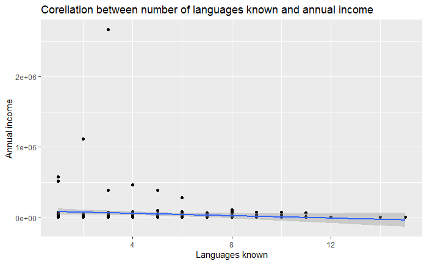

```r
ggplot(pros_omit, aes(x = langs_number, y = ConvertedCompYearly)) +
  geom_point()+
  geom_smooth(method = lm)+
  ggtitle("Corellation between number of languages known and annual income")+
  labs(x = "Languages known", y = "Annual income")
```

This data set includes some extreme values, such as 1 million or 2 million Euros. For reasons of simplicity let’s narrow down these values by setting a filter to yearly income and re-plot our results.

```r
pros_inc <- subset(pros_omit, pros_omit$ConvertedCompYearly < 80000)
view(pros_inc)
```

Create the scatter plot again

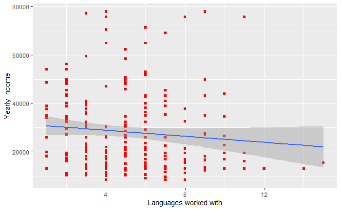

```r
ggplot(pros_inc, aes(x = langs_number, y = ConvertedCompYearly)) +
  geom_point(col = "red", pch = 15)+
  geom_smooth(method = lm)+
  labs(x = "Languages worked with", y = "Yearly Income")
```

```r
NA
```

By plotting the data, it is obvious that there is not a direct correlation between the number of languages known and previously used by developers and their annual income. Now, we will explore the potential correlation between income and years coding and age. First we have to clean those columns in order to explore our data. Then we will create a new plot

```r
pros_inc%>%
  na.omit(pros_inc$YearsCodePro)
```

|  | ResponseId | MainBranch | Employment | Country | EdLevel | Age1stCode | LearnCode | YearsCode | YearsCodePro | DevType | OrgSize | Currency | CompTotal | CompFreq | LanguageHaveWorkedWith | LanguageWantToWorkWith | DatabaseHaveWorkedWith | DatabaseWantToWorkWith | PlatformHaveWorkedWith | PlatformWantToWorkWith | WebframeHaveWorkedWith | WebframeWantToWorkWith | MiscTechHaveWorkedWith | MiscTechWantToWorkWith | ToolsTechHaveWorkedWith | ToolsTechWantToWorkWith | NEWCollabToolsHaveWorkedWith | NEWCollabToolsWantToWorkWith | OpSys | … |
| --- | --- | --- | --- | --- | --- | --- | --- | --- | --- | --- | --- | --- | --- | --- | --- | --- | --- | --- | --- | --- | --- | --- | --- | --- | --- | --- | --- | --- | --- | --- |
| 1 | 51 | I am a developer by profession | Employed full-time | Greece | Bachelor’s degree (B.A., B.S., B.Eng., etc.) | 18 - 24 years | Colleague | 12 | 6 | Developer, full-stack | 20 to 99 employees | EUR European Euro | 2000 | Monthly | C#;HTML/CSS;JavaScript;Node.js;PowerShell;TypeScript;VBA | HTML/CSS;JavaScript;Node.js;TypeScript | Couchbase;MariaDB;Microsoft SQL Server;MongoDB;MySQL;PostgreSQL;Redis;SQLite | Couchbase;Microsoft SQL Server;MongoDB;Redis;SQLite | AWS;DigitalOcean;Microsoft Azure | DigitalOcean | Angular;ASP.NET;ASP.NET Core ;Express;Svelte | Angular;Express;Gatsby;React.js;Svelte | .NET Framework;.NET Core / .NET 5 | Hadoop;React Native | Docker;Kubernetes | Docker;Terraform | Notepad++;Visual Studio;Visual Studio Code | Atom;Sublime Text;Visual Studio Code | Windows | … |
| 9 | 1146 | I am a developer by profession | Employed full-time | Greece | Bachelor’s degree (B.A., B.S., B.Eng., etc.) | 18 - 24 years | Coding Bootcamp | 2 | Less than 1 year | Developer, back-end | 20 to 99 employees | EUR European Euro | 650 | Monthly | C#;HTML/CSS;JavaScript;PowerShell | Bash/Shell;C#;JavaScript;PowerShell | Microsoft SQL Server | Microsoft SQL Server;MongoDB | Microsoft Azure | AWS;Google Cloud Platform;Microsoft Azure | ASP.NET;ASP.NET Core ;jQuery | ASP.NET;ASP.NET Core ;jQuery | .NET Framework;.NET Core / .NET 5 | .NET Framework;.NET Core / .NET 5 | Git;Unity 3D | Docker;Git | Visual Studio;Visual Studio Code | Visual Studio | Windows | … |
| 12 | 1648 | I am a developer by profession | Employed full-time | Greece | Master’s degree (M.A., M.S., M.Eng., MBA, etc.) | 5 - 10 years | Other online resources (ex: videos, blogs, etc);School;Friend or family member;Other (please specify): | 20 | 2 | Developer, full-stack;Developer, back-end | 20 to 99 employees | EUR European Euro | 1500 | Monthly | C#;HTML/CSS;JavaScript;Node.js | Assembly;C;C#;C++;JavaScript | Microsoft SQL Server;MongoDB | Microsoft SQL Server;MongoDB;PostgreSQL;SQLite | Microsoft Azure | Microsoft Azure | Angular;Angular.js;ASP.NET;jQuery;React.js | Angular;ASP.NET Core ;React.js;Vue.js | .NET Framework | .NET Core / .NET 5 | Git;Yarn | Docker;Git;Yarn | Atom;Visual Studio;Visual Studio Code | Atom;Eclipse;Notepad++;Visual Studio Code | Linux-based | … |
| 16 | 2411 | I am a developer by profession | Employed full-time | Greece | Master’s degree (M.A., M.S., M.Eng., MBA, etc.) | 11 - 17 years | School;Online Courses or Certification | 20 | 15 | Developer, mobile;Developer, front-end;Developer, full-stack;Developer, back-end;Developer, QA or test;DevOps specialist | 10 to 19 employees | EUR European Euro | 2500 | Monthly | Bash/Shell;Dart;HTML/CSS;Java;JavaScript;SQL | Java;SQL | Elasticsearch;Firebase;PostgreSQL | PostgreSQL | AWS | AWS | Vue.js | Vue.js | Cordova;Flutter | Flutter | Docker;Git | Docker;Git | Android Studio;IntelliJ | IntelliJ;Visual Studio Code | Windows | … |
| 19 | 2892 | I am a developer by profession | Employed full-time | Greece | Master’s degree (M.A., M.S., M.Eng., MBA, etc.) | 18 - 24 years | Other online resources (ex: videos, blogs, etc);School;Online Forum;Online Courses or Certification;Colleague | 14 | 6 | Developer, mobile;Developer, desktop or enterprise applications;Data or business analyst | 2 to 9 employees | EUR European Euro | 2000 | Monthly | C#;SQL;VBA | C#;SQL | Microsoft SQL Server | Elasticsearch;Firebase;Microsoft SQL Server;MongoDB;Redis | Microsoft Azure | AWS;Google Cloud Platform;Microsoft Azure | ASP.NET;ASP.NET Core | ASP.NET;ASP.NET Core | .NET Framework;.NET Core / .NET 5 | .NET Framework;.NET Core / .NET 5;Cordova;Flutter;Hadoop;TensorFlow | Xamarin | Git;Kubernetes;Xamarin | Visual Studio;Visual Studio Code | Visual Studio;Visual Studio Code | Windows | … |
| 23 | 4419 | I am a developer by profession | Employed full-time | Greece | Bachelor’s degree (B.A., B.S., B.Eng., etc.) | 11 - 17 years | Other online resources (ex: videos, blogs, etc);Online Courses or Certification | 9 | 6 | Developer, full-stack | 10 to 19 employees | EUR European Euro | 3000 | Monthly | C#;HTML/CSS;JavaScript;Node.js;PowerShell;SQL;TypeScript | C#;HTML/CSS;JavaScript;Node.js;SQL;TypeScript | Firebase;MongoDB;MySQL;Redis | Firebase;MongoDB;MySQL;Redis | AWS;Heroku;Microsoft Azure | AWS;Heroku | Angular;Angular.js;ASP.NET Core ;Express;jQuery;Vue.js | Angular;ASP.NET Core ;Express | .NET Framework;.NET Core / .NET 5 | .NET Core / .NET 5 | Docker;Git | Docker;Git;Kubernetes | Visual Studio;Visual Studio Code | Visual Studio Code | Windows | … |
| 29 | 5295 | I am a developer by profession | Employed full-time | Greece | Bachelor’s degree (B.A., B.S., B.Eng., etc.) | 18 - 24 years | Other online resources (ex: videos, blogs, etc);School;Online Courses or Certification;Books / Physical media | 7 | 3 | Developer, back-end | 100 to 499 employees | EUR European Euro | 24500 | Yearly | C#;Java;JavaScript;LISP;Node.js;PowerShell;Python;SQL;TypeScript;VBA | Go;Rust;Scala | Microsoft SQL Server;PostgreSQL;Redis | Cassandra;Elasticsearch;MongoDB | Microsoft Azure | Heroku | Angular.js;ASP.NET;ASP.NET Core ;Express | React.js | .NET Framework;.NET Core / .NET 5 | Apache Spark;Hadoop;Keras;NumPy;Pandas;TensorFlow | Ansible;Docker;Git | Unity 3D;Unreal Engine | IntelliJ;PyCharm;Rider;Vim;Visual Studio Code | IntelliJ;Neovim;PyCharm;Rider;Vim | Linux-based | … |
| 41 | 12781 | I am a developer by profession | Employed full-time | Greece | Bachelor’s degree (B.A., B.S., B.Eng., etc.) | 5 - 10 years | Colleague | 4 | 4 | Developer, mobile;Developer, front-end;Developer, full-stack;Developer, back-end;Product manager | 10 to 19 employees | EUR European Euro | 1300 | Monthly | C#;SQL | C#;SQL | MySQL | MongoDB;MySQL | Microsoft Azure | Microsoft Azure | ASP.NET;ASP.NET Core | ASP.NET;ASP.NET Core | .NET Framework;.NET Core / .NET 5 | .NET Framework;.NET Core / .NET 5 | Git;Xamarin | Git;Xamarin | Notepad++;Visual Studio | Notepad++;Visual Studio | Windows | … |
| 46 | 13468 | I am a developer by profession | Employed full-time | Greece | Associate degree (A.A., A.S., etc.) | 25 - 34 years | Coding Bootcamp | 2 | 1 | Developer, desktop or enterprise applications;Engineer, data | 100 to 499 employees | EUR European Euro | 1000 | Monthly | Assembly;C;C#;SQL | F#;PowerShell;TypeScript | Microsoft SQL Server | DynamoDB;MongoDB;Redis | Heroku;Microsoft Azure | AWS | ASP.NET;ASP.NET Core ;jQuery | Angular;Angular.js;Vue.js | .NET Framework;.NET Core / .NET 5 | Apache Spark;Hadoop | Git | Docker;Kubernetes;Xamarin | Visual Studio;Visual Studio Code | IntelliJ | Windows | … |
| 47 | 13523 | I am a developer by profession | Employed full-time | Greece | Master’s degree (M.A., M.S., M.Eng., MBA, etc.) | 11 - 17 years | Friend or family member | 7 | 2 | Developer, back-end;Student;DevOps specialist | 20 to 99 employees | EUR European Euro | 1300 | Monthly | Java;JavaScript;Python;SQL | Go;Java;Python;Rust;TypeScript | Microsoft SQL Server;Redis | MySQL | AWS | AWS;Microsoft Azure | Spring;Vue.js | Flask;Spring;Vue.js | Apache Spark;Keras;NumPy;Pandas | Apache Spark;Hadoop;React Native | Docker;Git | Ansible;Docker;Git;Kubernetes;Puppet;Terraform;Yarn | Android Studio;Eclipse;IntelliJ;PyCharm;Vim;Visual Studio Code;Webstorm | IntelliJ;PyCharm;Vim;Visual Studio Code;Webstorm | Linux-based | … |

[output cut: 38 more lines]

```r
isTRUE(is.na(pros_inc$YearsCodePro))
```

```
[1] FALSE
```

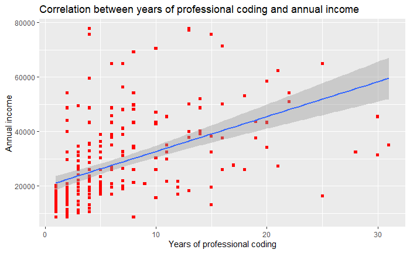

```r
pros_inc$YearsCodePro[pros_inc$YearsCodePro == "Less than 1 year"] <- 1 ## replace "Less than 1 year" string with 1
view(pros_inc)
pros_inc$YearsCodePro<- as.numeric(pros_inc$YearsCodePro)
view(pros_inc)
ggplot(pros_inc, aes(x = YearsCodePro, y = ConvertedCompYearly))+
  geom_point(col = "red", pch = 15)+
  geom_smooth(method = lm)+
  ggtitle("Correlation between years of professional coding and annual income")+
  labs(x = "Years of professional coding", y = "Annual income")
```

In this particular case, a small trend seems to exist between the two variables, as in some cases, more years of coding experience lead to a better yearly salary. However, this result definitely does not provide a secure answer and more sophisticated methods should be applied, which lie beyond this small case study.

Now, let’s create some visualizations in order to explore our data

Density of developer’s age groups based on their yearly income:

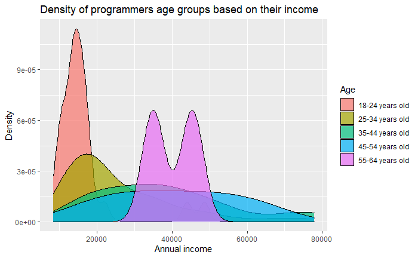

```r
ggplot(pros_inc, aes(x = ConvertedCompYearly, fill = Age))+
  geom_density(alpha= .7)+
  ggtitle("Density of programmers age groups based on their income")+
  labs(x = "Annual income", y = "Density")
```

It is obvious that most developers between 18-24 years old earn less than 20k euros per year, with only a small number of them earning more than this amount. The graph gives some excellent result about Greek professional developers which need to be explored in more depth.

In the same way, we can further explore our data and answer some simple (at the beginning) questions regarding the situation with Greek professional developers. For example, we can check with some simple plots the differences between gender, education or other similar issues.